##GROUP 14 - CUSTOMER SEGMENTATION AND SALES ANALYSIS WITH PRODUCT RECOMMENDATION

TEAM MEMBERS

1. ATUL SHARMA
2. MOUNIKA REDDY KATIKAM VENKATA
3. VAIBHAV BANSAL
4. DEVENDRA RANA

```r
library(readr)
library(dplyr)
```

```r
library(ggplot2)
library(DataExplorer)
library(tidyverse)
library(cluster)
library(factoextra)
library(caret)
custData <- read_csv("review_added_data.csv")
glimpse(custData)
```

```
## Rows: 541,909
## Columns: 13
## $ InvoiceNo          <chr> "558484", "558484", "558484", "558484", "558484", "…
## $ StockCode          <chr> "23298", "22423", "23245", "22956", "21164", "22776…
## $ Description        <chr> "SPOTTY BUNTING", "REGENCY CAKESTAND 3 TIER", "SET …
## $ Quantity           <dbl> 6, 6, 8, 6, 6, -1, -12, -1, -1, -6, -12, -6, -6, -6…
## $ InvoiceDate        <dttm> 2011-06-30 10:09:00, 2011-06-30 10:09:00, 2011-06-…
## $ UnitPrice          <dbl> 4.95, 12.75, 4.95, 2.10, 2.95, 9.95, 1.45, 0.85, 4.…
## $ CustomerID         <dbl> 14267, 14267, 14267, 14267, 14267, 14267, 14267, 14…
## $ Country            <chr> "United Kingdom", "United Kingdom", "United Kingdom…
## $ Gender             <chr> "Female", "Female", "Female", "Female", "Female", "…
## $ Age                <dbl> 17, 17, 17, 17, 17, 17, 17, 17, 17, 17, 17, 17, 17,…
## $ PaymentMethod      <chr> "PayPal", "PayPal", "PayPal", "PayPal", "PayPal", "…
## $ Previous_Purchases <dbl> 2, 2, 2, 2, 2, 3, 4, 5, 5, 6, 6, 6, 6, 6, 6, 6, 0, …
## $ review             <chr> "It's an unfortunate SPOTTY BUNTING. This SPOTTY BU…
```

```r
dim(custData)
```

```
## [1] 541909     13
```

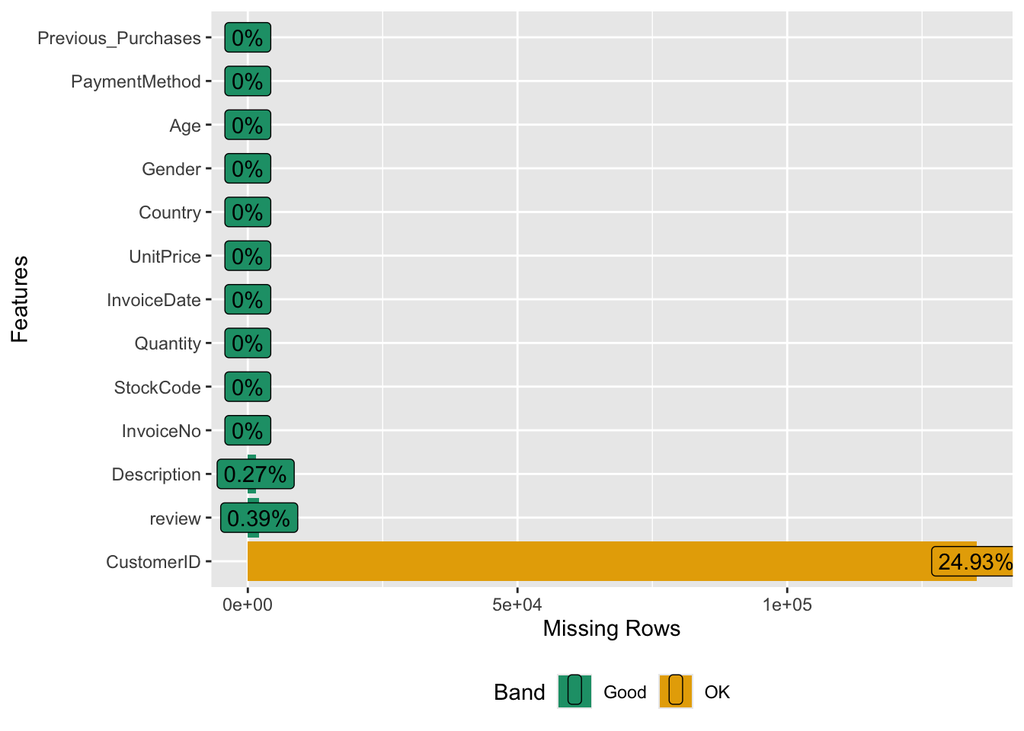

```r
options(repr.plot.width=8, repr.plot.height=3)
# look for missing values using the DataExplorer package
plot_missing(custData)
```

**Looking at the size of the dataset and the missing value plot, it seems as if we can remove the missing values and still have a good-sized set of data to work on, so let’s start by doing that:**

```r
custData <- na.omit(custData)
dim(custData)
```

```
## [1] 405248     13
```

```r
# separate date and time components of invoice date
# Ensure InvoiceDate is character
custData$InvoiceDate <- as.character(custData$InvoiceDate)

# Split InvoiceDate into date and time
custData$date <- sapply(custData$InvoiceDate, FUN = function(x) {strsplit(x, split = ' ')[[1]][1]})
custData$time <- sapply(custData$InvoiceDate, FUN = function(x) {strsplit(x, split = ' ')[[1]][2]})
```

```r
# create month, year and hour of day variables
custData$month <- sapply(custData$date, FUN = function(x) {strsplit(x, split = '[/]')[[1]][1]})
custData$year <- sapply(custData$date, FUN = function(x) {strsplit(x, split = '[/]')[[1]][3]})
custData$hourOfDay <- sapply(custData$time, FUN = function(x) {strsplit(x, split = '[:]')[[1]][1]})
```

```r
head(custData, n =5)
```

```
## # A tibble: 5 × 18
##   InvoiceNo StockCode Description      Quantity InvoiceDate UnitPrice CustomerID
##   <chr>     <chr>     <chr>               <dbl> <chr>           <dbl>      <dbl>
## 1 558484    23298     SPOTTY BUNTING          6 2011-06-30…      4.95      14267
## 2 558484    22423     REGENCY CAKESTA…        6 2011-06-30…     12.8       14267
## 3 558484    23245     SET OF 3 REGENC…        8 2011-06-30…      4.95      14267
## 4 558484    22956     36 FOIL HEART C…        6 2011-06-30…      2.1       14267
## 5 558484    21164     HOME SWEET HOME…        6 2011-06-30…      2.95      14267
## # ℹ 11 more variables: Country <chr>, Gender <chr>, Age <dbl>,
## #   PaymentMethod <chr>, Previous_Purchases <dbl>, review <chr>, date <chr>,
## #   time <chr>, month <chr>, year <chr>, hourOfDay <chr>
```

Okay, that’s pulled out some more useful components from our invoice date column, but let’s convert the date variable to the appopriate class so we can do a bit more with it:

```r
custData$date <- as.Date(custData$date, "%m/%d/%Y")
```

```r
library(lubridate)
custData$dayOfWeek <- wday(custData$date, label=TRUE)
```

```r
custData <- custData %>% mutate(lineTotal = Quantity * UnitPrice)
```

```r
head(custData)
```

```
## # A tibble: 6 × 20
##   InvoiceNo StockCode Description      Quantity InvoiceDate UnitPrice CustomerID
##   <chr>     <chr>     <chr>               <dbl> <chr>           <dbl>      <dbl>
## 1 558484    23298     SPOTTY BUNTING          6 2011-06-30…      4.95      14267
## 2 558484    22423     REGENCY CAKESTA…        6 2011-06-30…     12.8       14267
## 3 558484    23245     SET OF 3 REGENC…        8 2011-06-30…      4.95      14267
## 4 558484    22956     36 FOIL HEART C…        6 2011-06-30…      2.1       14267
## 5 558484    21164     HOME SWEET HOME…        6 2011-06-30…      2.95      14267
## 6 C548471   22776     SWEETHEART CAKE…       -1 2011-03-31…      9.95      14267
## # ℹ 13 more variables: Country <chr>, Gender <chr>, Age <dbl>,
## #   PaymentMethod <chr>, Previous_Purchases <dbl>, review <chr>, date <date>,
## #   time <chr>, month <chr>, year <chr>, hourOfDay <chr>, dayOfWeek <ord>,
## #   lineTotal <dbl>
```

That’s given us a good dataframe to start performing some summary analyses. But before we move on to getting involved with product and customer segmentation, we’ll look at some of the bigger features of the dataset. First, we’ll turn the appropriate variables into factors:

```r
custData$Country <- as.factor(custData$Country)
custData$month <- as.factor(custData$month)
custData$year <- as.factor(custData$year)
levels(custData$year) <- c(2010,2011)
custData$hourOfDay <- as.factor(custData$hourOfDay)
custData$dayOfWeek <- as.factor(custData$dayOfWeek)
```

That done, we can take a look at some of the ‘big picture’ aspects of the dataset.

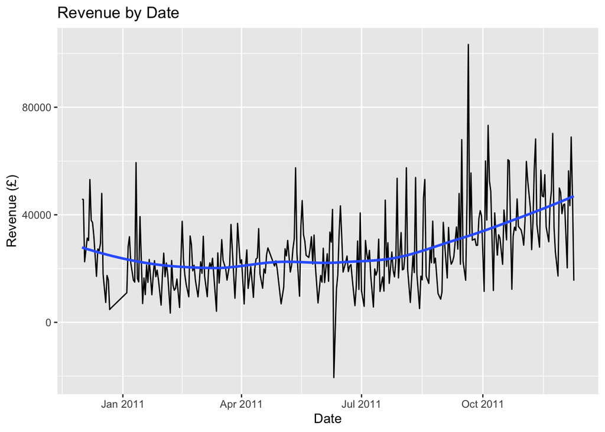

```r
custData$InvoiceDate <- as.character(custData$InvoiceDate)
custData$date <- sapply(custData$InvoiceDate, FUN = function(x) {strsplit(x, split = ' ')[[1]][1]})

# Convert date to Date type and handle invalid dates
custData$date <- ymd(custData$date)

# Check for any NA values in the date column
if (any(is.na(custData$date))) {
  cat("There are invalid dates in the data. Rows with invalid dates will be removed.\n")
  print(custData[is.na(custData$date), ])

  # Remove rows with NA dates
  custData <- custData %>% filter(!is.na(date))
}

# Summarize revenue by date
revenue_by_date <- custData %>%
  group_by(date) %>%
  summarise(revenue = sum(lineTotal, na.rm = TRUE))

# Plot the data
options(repr.plot.width=8, repr.plot.height=3)
ggplot(revenue_by_date, aes(x = date, y = revenue)) +
  geom_line() +
  geom_smooth(method = 'auto', se = FALSE) +
  labs(x = 'Date', y = 'Revenue (£)', title = 'Revenue by Date')
```

It appears as though sales are trending up, so that’s a good sign, but that doesn’t really generate any actionable insight, so let’s dive into the data a bit farther…

Day of week analysis Using the lubridate package, we assigned a day of the week to each date in our dataset. I don’t know about you, but I’m certainly in a different frame of mind as the week goes on. Are people more likely to spend as the week goes on? Browsing to pass a Sunday afternoon? Procrastinating on that Friday afternoon at work? Cheering yourself up after a difficult Monday?

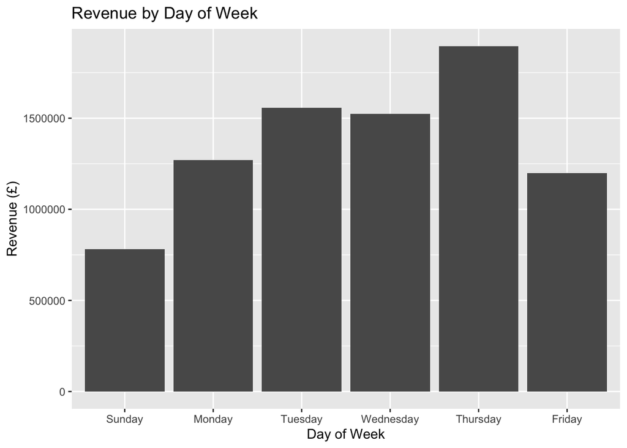

```r
custData$InvoiceDate <- as.character(custData$InvoiceDate)
custData$date <- sapply(custData$InvoiceDate, FUN = function(x) {strsplit(x, split = ' ')[[1]][1]})
custData$date <- ymd(custData$date)

# Check for any invalid dates and remove rows with NA dates
if (any(is.na(custData$date))) {
  cat("There are invalid dates in the data. Rows with invalid dates will be removed.\n")
  print(custData[is.na(custData$date), ])
  custData <- custData %>% filter(!is.na(date))
}

# Extract the day of the week
custData$dayOfWeek <- wday(custData$date, label = TRUE, abbr = FALSE)

# Summarize revenue by day of the week
revenue_by_dayOfWeek <- custData %>%
  group_by(dayOfWeek) %>%
  summarise(revenue = sum(lineTotal, na.rm = TRUE))

# Plot the data
options(repr.plot.width=8, repr.plot.height=3)
ggplot(revenue_by_dayOfWeek, aes(x = dayOfWeek, y = revenue)) +
  geom_col() +
  labs(x = 'Day of Week', y = 'Revenue (£)', title = 'Revenue by Day of Week')
```

```r
weekdaySummary <- custData %>%
  group_by(date, dayOfWeek) %>%
  summarise(revenue = sum(lineTotal), transactions = n_distinct(InvoiceNo)) %>%
  mutate(aveOrdVal = (round((revenue / transactions),2))) %>%
  ungroup()
head(weekdaySummary, n = 10)
```

```
## # A tibble: 10 × 5
##    date       dayOfWeek revenue transactions aveOrdVal
##    <date>     <ord>       <dbl>        <int>     <dbl>
##  1 2010-12-01 Wednesday  45834.          127      361.
##  2 2010-12-02 Thursday   45692.          160      286.
##  3 2010-12-03 Friday     22533.           64      352.
##  4 2010-12-05 Sunday     31337.           94      333.
##  5 2010-12-06 Monday     30442.          111      274.
##  6 2010-12-07 Tuesday    53115.           79      672.
##  7 2010-12-08 Wednesday  37971.          134      283.
##  8 2010-12-09 Thursday   37122.          132      281.
##  9 2010-12-10 Friday     32054.           78      411.
## 10 2010-12-12 Sunday     17104.           50      342.
```

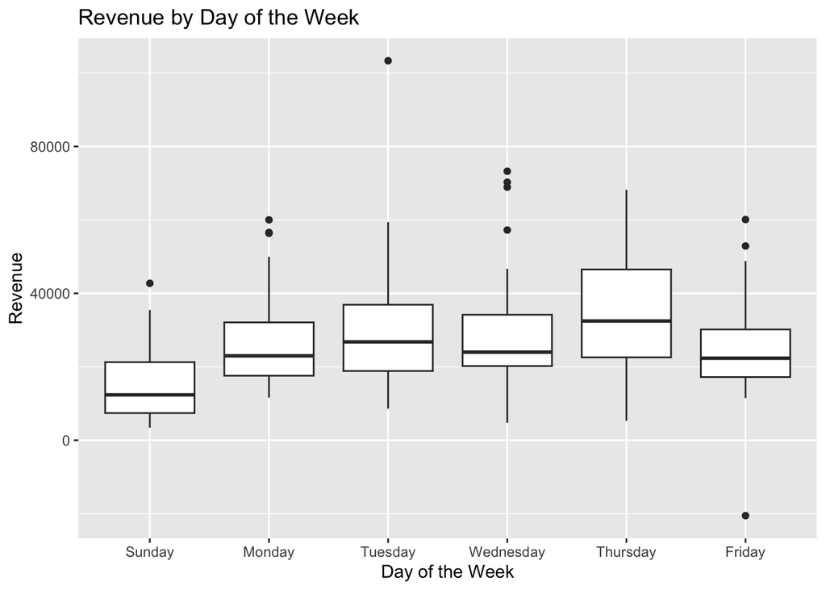

```r
ggplot(weekdaySummary, aes(x = dayOfWeek, y = revenue)) + geom_boxplot() + labs(x = 'Day of the Week', y = 'Revenue', title = 'Revenue by Day of the Week')
```

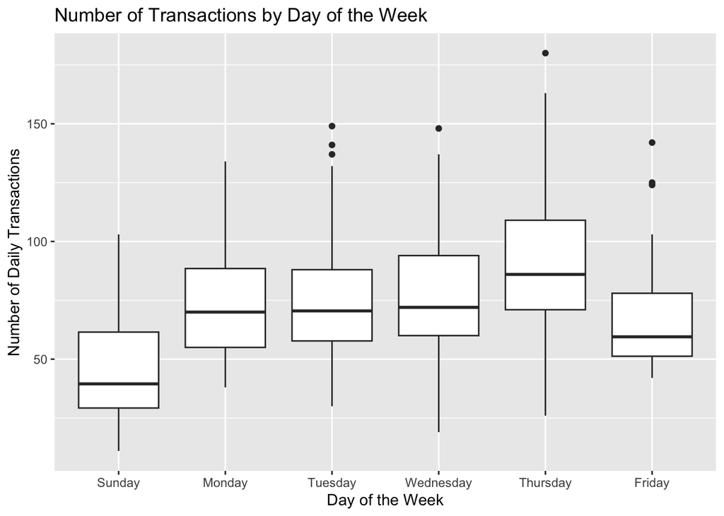

```r
ggplot(weekdaySummary, aes(x = dayOfWeek, y = transactions)) + geom_boxplot() + labs(x = 'Day of the Week', y = 'Number of Daily Transactions', title = 'Number of Transactions by Day of the Week')
```

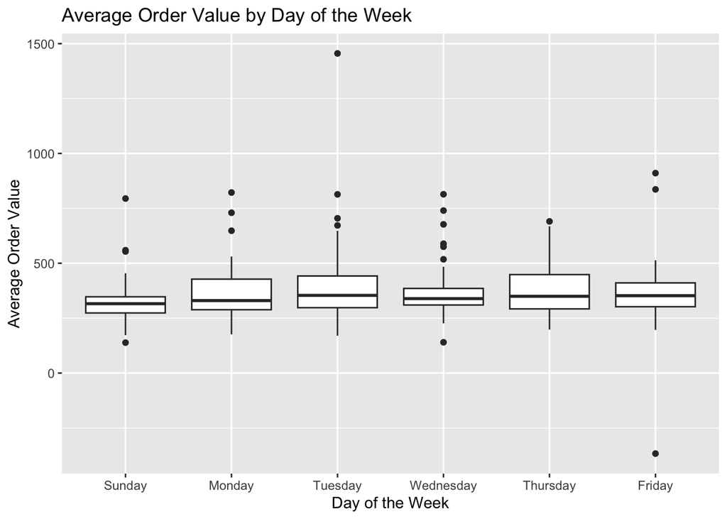

```r
ggplot(weekdaySummary, aes(x = dayOfWeek, y = aveOrdVal)) + geom_boxplot() + labs(x = 'Day of the Week', y = 'Average Order Value', title = 'Average Order Value by Day of the Week')
```

Eye-balling the figures, it looks as though there are differences in the amount of revenue on each day of the week, and that this difference is driven by a difference in the number of transactions, rather than the average order value. Let’s plot the data as a density plot to get a better feel for how these data are distributed.

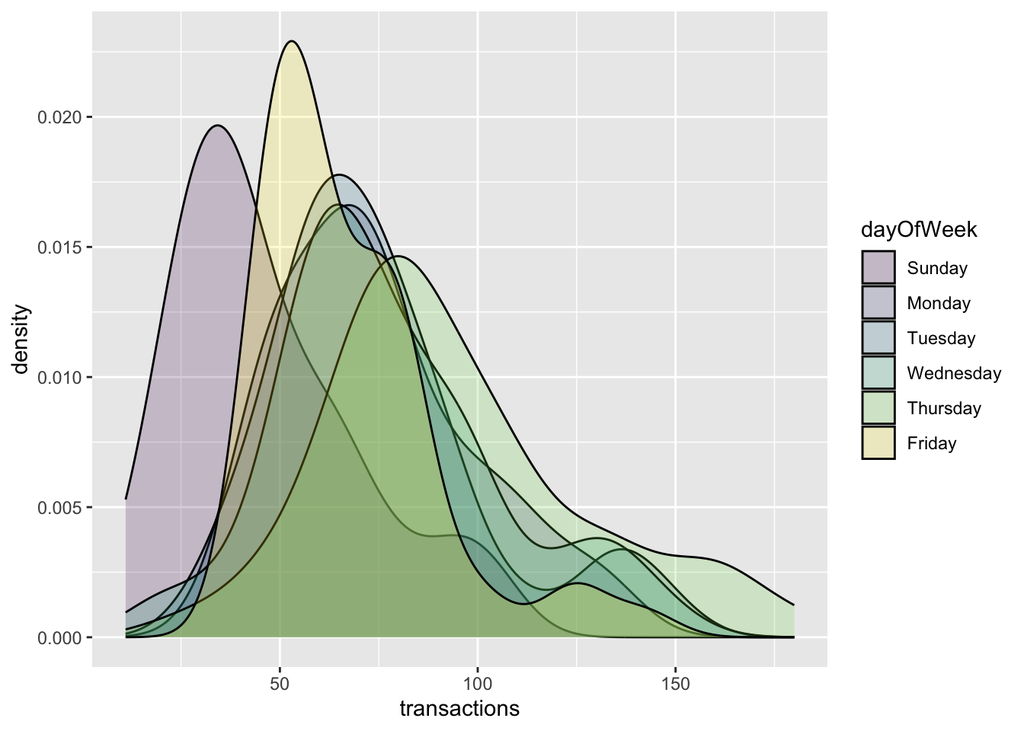

```r
ggplot(weekdaySummary, aes(transactions, fill = dayOfWeek)) + geom_density(alpha = 0.2)
```

```r
kruskal.test(transactions ~ dayOfWeek, data = weekdaySummary)
```

```
##
##  Kruskal-Wallis rank sum test
##
## data:  transactions by dayOfWeek
## Kruskal-Wallis chi-squared = 71.761, df = 5, p-value = 4.406e-14
```

Looks like a significant difference there, that’s quite a p-value we’ve got. Using the kruskal function from the agricolae package, we can look to see which days are significantly different from the others:

```r
library(agricolae)
kruskal(weekdaySummary$transactions, weekdaySummary$dayOfWeek, console = TRUE)
```

```
##
## Study: weekdaySummary$transactions ~ weekdaySummary$dayOfWeek
## Kruskal-Wallis test's
## Ties or no Ties
##
## Critical Value: 71.76077
## Degrees of freedom: 5
## Pvalue Chisq  : 4.407585e-14
##
## weekdaySummary$dayOfWeek,  means of the ranks
##
##           weekdaySummary.transactions  r
## Friday                       134.8400 50
## Monday                       162.3830 47
## Sunday                        72.4900 50
## Thursday                     213.6792 53
## Tuesday                      160.1538 52
## Wednesday                    170.0660 53
##
## Post Hoc Analysis
##
## t-Student: 1.96793
## Alpha    : 0.05
## Groups according to probability of treatment differences and alpha level.
##
## Treatments with the same letter are not significantly different.
##
##           weekdaySummary$transactions groups
## Thursday                     213.6792      a
## Wednesday                    170.0660      b
## Monday                       162.3830     bc
## Tuesday                      160.1538     bc
## Friday                       134.8400      c
## Sunday                        72.4900      d
```

By looking at our data at the level of weekday, we can see that there are statistically significant differences in the number of transactions that take place on different days of the week, with Sunday having the lowest number of transactions, and Thursday the highest. As the average order value remains relatively consistent, this translates to differences in revenue.

Given the low number of transactions on a Sunday and a high number on a Thursday, we could make recommendations around our digital advertising spend. Should we spend less on a Sunday and more on a Thursday, given that we know we already have more transactions, which could suggest people are more ready to buy on Thursdays? Possible, but without knowing other key metrics, it might be a bit hasty to say.

While this data does reveal insight, in order to be truly actionable, we would want to combine this with more information. In particular, combining these data with web analytics data would be hugely valuable. How do these data correlate with web traffic figures? Does the conversion rate change or is there just more traffic on a Thursday and less on a Sunday?

What about out current advertising spend? Is the company already spending less on a Sunday and more on a Thursday and that is behind our observed differences? What about buying cycles? How long does it take for a customer to go from thinking about buying something to buying it? If it’s usually a couple of days, should we advertise more on a Tuesday? Should we continue with an increased spend on a Thursday, when they’re ready to buy, and let our competitors pay for the clicks while the customer is in the ‘research’ stage of the process?

These types of questions illustrate the importance of understanding the vertical, the business model and other factors and decisions which underpin the dataset, rather than just looking at the dataset in isolation.

Hour of day analysis In a similar way to our day-of-the-week analysis, is there insight to be had from looking at the hours of the day?

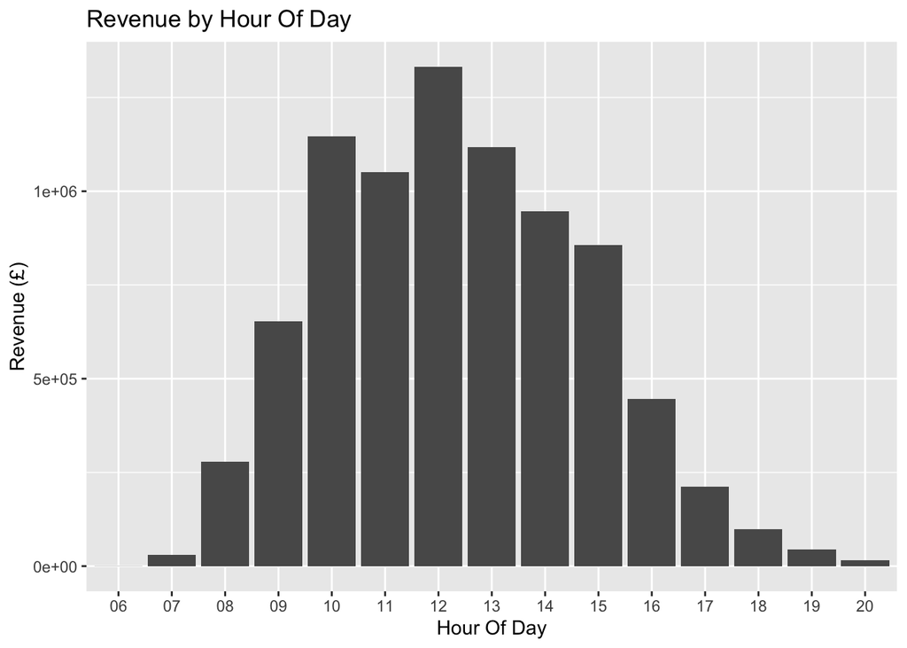

```r
custData %>%
  group_by(hourOfDay) %>%
  summarise(revenue = sum(lineTotal)) %>%
  ggplot(aes(x = hourOfDay, y = revenue)) + geom_col() + labs(x = 'Hour Of Day', y = 'Revenue (£)', title = 'Revenue by Hour Of Day')
```

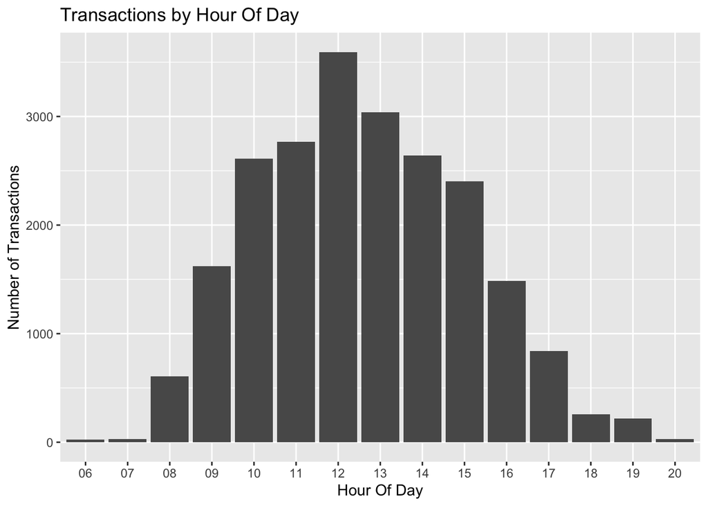

```r
custData %>%
  group_by(hourOfDay) %>%
  summarise(transactions = n_distinct(InvoiceNo)) %>%
  ggplot(aes(x = hourOfDay, y = transactions)) + geom_col() + labs(x = 'Hour Of Day', y = 'Number of Transactions', title = 'Transactions by Hour Of Day')
```

As the type of analysis we would do here is similar to what we did with the dayOfWeek, we’ll leave this for now, knowing that there is a daily trend, and there is likely some actionable insight we could draw if we had some more information.

Country summary Our e-commerce retailer ships to a number of countries around the world. Let’s drill into the data from that perspective and see what we can find out.

```r
countrySummary <- custData %>%
  group_by(Country) %>%
  summarise(revenue = sum(lineTotal), transactions = n_distinct(InvoiceNo)) %>%
  mutate(aveOrdVal = (round((revenue / transactions),2))) %>%
  ungroup() %>%
  arrange(desc(revenue))

head(countrySummary, n = 10)
```

```
## # A tibble: 10 × 4
##    Country         revenue transactions aveOrdVal
##    <fct>             <dbl>        <int>     <dbl>
##  1 United Kingdom 6700619.        19841      338.
##  2 Netherlands     283382.          101     2806.
##  3 EIRE            249370.          316      789.
##  4 Germany         220980.          603      366.
##  5 France          195320.          457      427.
##  6 Australia       136197.           69     1974.
##  7 Switzerland      55565.           71      783.
##  8 Spain            54521.          105      519.
##  9 Belgium          40806.          119      343.
## 10 Sweden           36392.           45      809.
```

```r
unique(countrySummary$Country)
```

```
##  [1] United Kingdom       Netherlands          EIRE
##  [4] Germany              France               Australia
##  [7] Switzerland          Spain                Belgium
## [10] Sweden               Japan                Norway
## [13] Portugal             Finland              Channel Islands
## [16] Denmark              Italy                Cyprus
## [19] Austria              Singapore            Poland
## [22] Israel               Greece               Iceland
## [25] Canada               Unspecified          Malta
## [28] United Arab Emirates USA                  Lebanon
## [31] Lithuania            European Community   Brazil
## [34] RSA                  Czech Republic       Bahrain
## [37] Saudi Arabia
## 37 Levels: Australia Austria Bahrain Belgium Brazil Canada ... USA
```

```r
countryCustSummary <- custData %>%
  group_by(Country) %>%
  summarise(revenue = sum(lineTotal), customers = n_distinct(CustomerID)) %>%
  mutate(aveCustVal = (round((revenue / customers),2))) %>%
  ungroup() %>%
  arrange(desc(revenue))

head(countryCustSummary, n = 10)
```

```
## # A tibble: 10 × 4
##    Country         revenue customers aveCustVal
##    <fct>             <dbl>     <int>      <dbl>
##  1 United Kingdom 6700619.      3948      1697.
##  2 Netherlands     283382.         9     31487.
##  3 EIRE            249370.         3     83123.
##  4 Germany         220980.        95      2326.
##  5 France          195320.        87      2245.
##  6 Australia       136197.         9     15133.
##  7 Switzerland      55565.        21      2646.
##  8 Spain            54521.        31      1759.
##  9 Belgium          40806.        25      1632.
## 10 Sweden           36392.         8      4549.
```

Plenty to see there, ceratinly. A lot of different countries contributing a good amount of revenue. As it seems that refunds and/or cancellations are present in the dataset as revenue with a negative value (not shown in this notebook, but you can dive in yourself), we can assume that the revenue figures here are net of refunds; something that it is important to consider when shipping goods overseas. However, additional information on the costs incurred dealing with these refunds would allow us to make more appropriate recommendations.

Let’s begin by looking at the top five countries in terms of revenue contribution. We’ll exclude the UK as we know that this is a UK retailer, so improving UK performance will undoubtedly already be on the radar. Looking at the top five non-UK by revenue, the lowest number of transactions is 69 (Australia), which, given the time period of the dataset, is still a regular number of transactions, so the inclusion of these countries seems justified.

```r
topFiveCountries <- custData %>%
  filter(Country == 'Netherlands' | Country == 'EIRE' | Country == 'Germany' | Country == 'France' | Country == 'Australia')
```

```r
topFiveCountrySummary <- topFiveCountries %>%
  group_by(Country, date) %>%
  summarise(revenue = sum(lineTotal), transactions = n_distinct(InvoiceNo), customers = n_distinct(CustomerID)) %>%
  mutate(aveOrdVal = (round((revenue / transactions),2))) %>%
  ungroup() %>%
  arrange(desc(revenue))
head(topFiveCountrySummary)
```

```
## # A tibble: 6 × 6
##   Country     date       revenue transactions customers aveOrdVal
##   <fct>       <date>       <dbl>        <int>     <int>     <dbl>
## 1 Netherlands 2011-10-20  25754.            3         1     8585.
## 2 Australia   2011-06-15  23168.            2         1    11584.
## 3 Australia   2011-08-18  21880.            1         1    21880.
## 4 Netherlands 2011-08-11  19151.            1         1    19151.
## 5 Netherlands 2011-02-21  18279.            2         1     9140.
## 6 Netherlands 2011-03-29  18147.            2         1     9073.
```

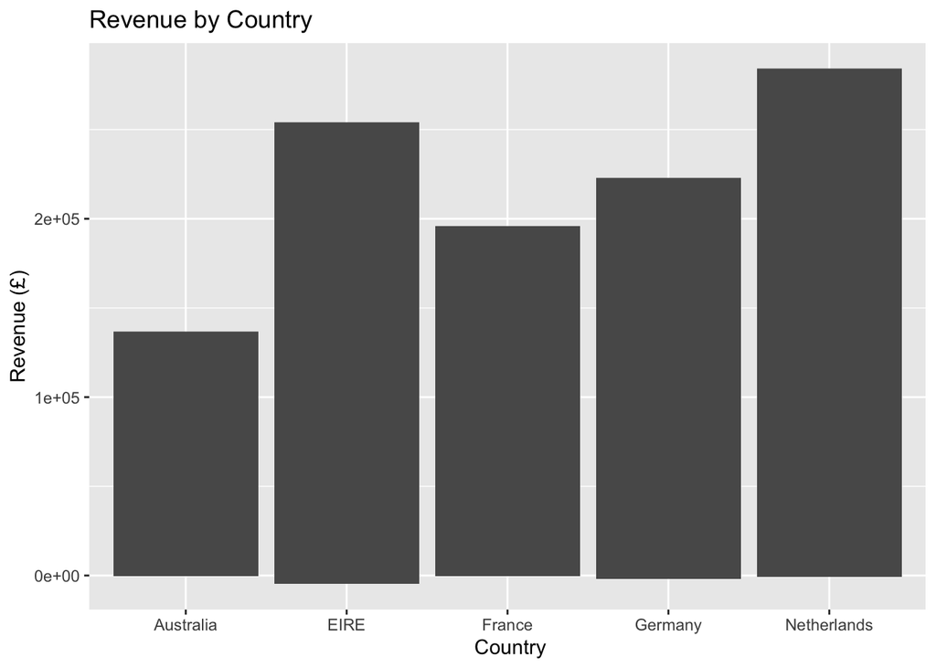

```r
ggplot(topFiveCountrySummary, aes(x = Country, y = revenue)) + geom_col() + labs(x = ' Country', y = 'Revenue (£)', title = 'Revenue by Country')
```

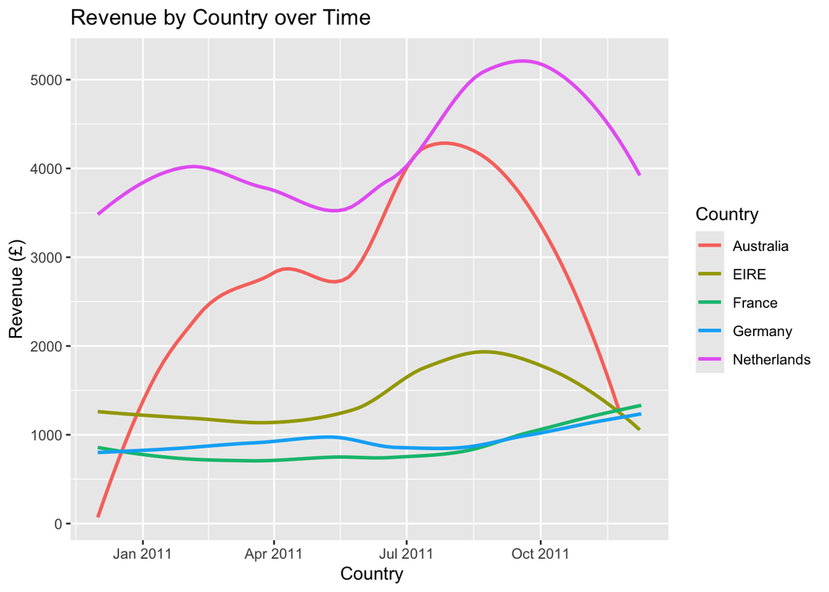

```r
ggplot(topFiveCountrySummary, aes(x = date, y = revenue, colour = Country)) + geom_smooth(method = 'auto', se = FALSE) + labs(x = ' Country', y = 'Revenue (£)', title = 'Revenue by Country over Time')
```

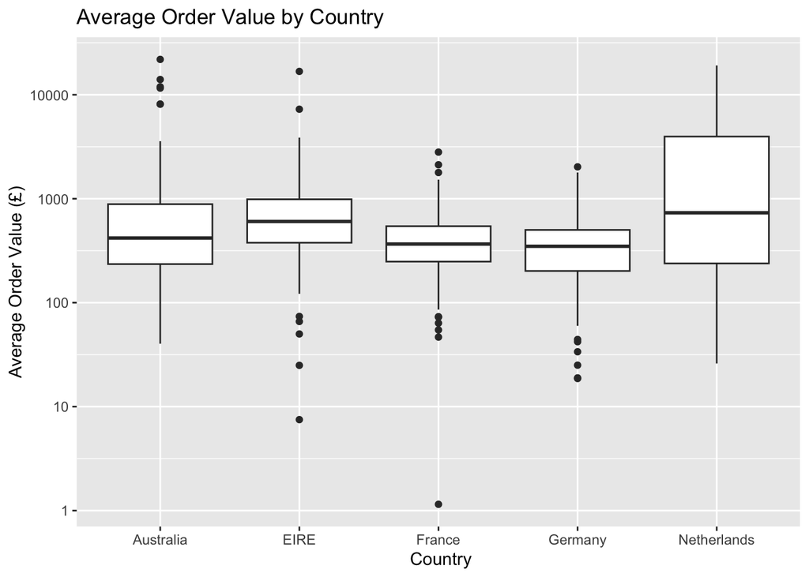

```r
ggplot(topFiveCountrySummary, aes(x = Country, y = aveOrdVal)) + geom_boxplot() + labs(x = ' Country', y = 'Average Order Value (£)', title = 'Average Order Value by Country') + scale_y_log10()
```

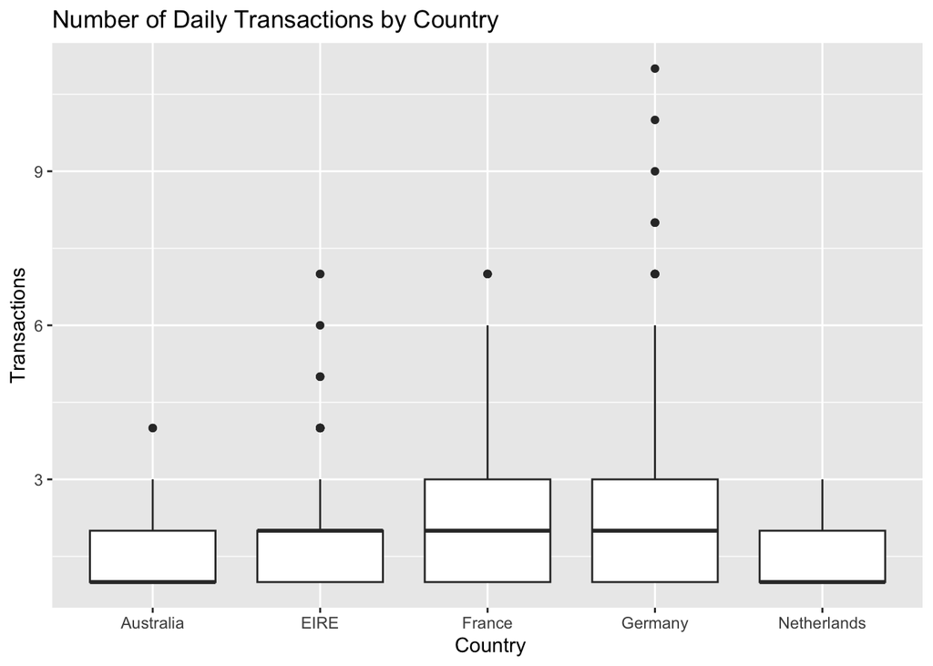

```r
ggplot(topFiveCountrySummary, aes(x = Country, y = transactions)) + geom_boxplot() + labs(x = ' Country', y = 'Transactions', title = 'Number of Daily Transactions by Country')
```

These simple analyses show that there are opportunities. Revenue in EIRE seems to be driven by 3 customers, who buy regularly and have a good average order value, but EIRE revenue has been declining recently. Given the small number of customers and high revenue, a bespoke email or promotion to these customers may drive loyalty and get them buying again.

The Netherlands has also been a significant source of revenue, but another which has been declining in the last few months of the dataset. Further research into this (marketing campaign activity and web analytics data) may provide further insight into why this may be the case, but it does appear that, as customers in the Netherlands have shown a willingness to purchase in the past, the country represents a good opportunity to market to to continue to build a loyal customer base.

France and Germany represent significant opportunities. Revenue from these countries has been rising, and the number of daily transactions is [relatively] strong. Marketing campaigns which aim to improve this while increasing average transaction values may be of significant benefit.

Customer segmentation¶ When it comes to marketing, being able to segment your customers so that you can market appropriate products and offers to them is a quick win. There is little point in sending a potential student who has been browsing nursing courses on your university site an email espousing the USPs of your fine arts courses.

In this dataset, we have the customer ID, which we can use to start looking for differences between customers. While we have product IDs and descriptions, we are lacking in a simple product category ID. There is information we can extract from other fields, but that may be beyond the scope of this kernel, which is already getting a little long!

Let’s look at our customer data from the point of view of loyalty. If we can identify a group of customers who shop regularly, we can target this group with dedicated marketing campaigns which may reinforce their loyalty, and perhaps lead to them becoming brand ambassodors on social media.

```r
custSummary <- custData %>%
  group_by(CustomerID) %>%
  summarise(revenue = sum(lineTotal), transactions = n_distinct(InvoiceNo)) %>%
  mutate(aveOrdVal = (round((revenue / transactions),2))) %>%
  ungroup() %>%
  arrange(desc(revenue))

head(custSummary, n = 10)
```

```
## # A tibble: 10 × 4
##    CustomerID revenue transactions aveOrdVal
##         <dbl>   <dbl>        <int>     <dbl>
##  1      14646 278222.           77     3613.
##  2      18102 251939.           62     4064.
##  3      17450 187482.           55     3409.
##  4      14911 131947.          245      539.
##  5      12415 122944.           26     4729.
##  6      14156 113114.           66     1714.
##  7      17511  87961.           46     1912.
##  8      16684  65892.           31     2126.
##  9      13694  62597.           60     1043.
## 10      15311  58945.          118      500.
```

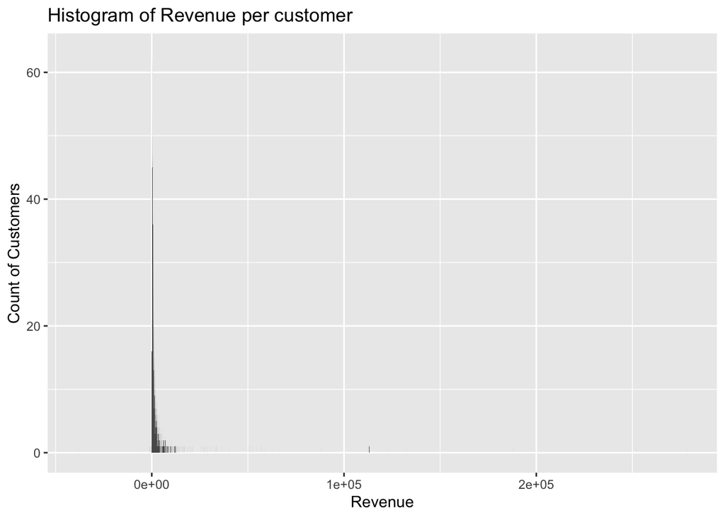

```r
ggplot(custSummary, aes(revenue)) + geom_histogram(binwidth = 10) + labs(x = 'Revenue', y = 'Count of Customers', title = 'Histogram of Revenue per customer')
```

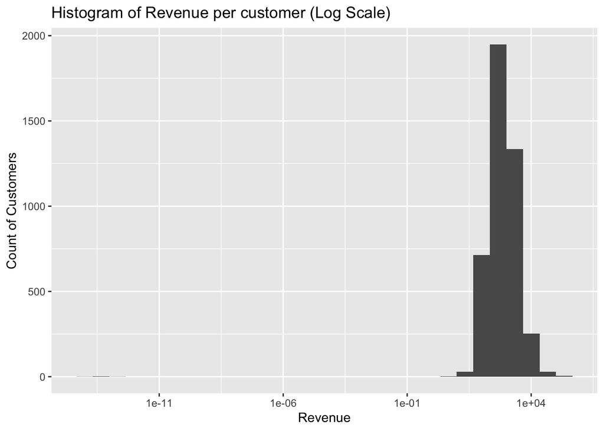

```r
ggplot(custSummary, aes(revenue)) + geom_histogram() + scale_x_log10() + labs(x = 'Revenue', y = 'Count of Customers', title = 'Histogram of Revenue per customer (Log Scale)')
```

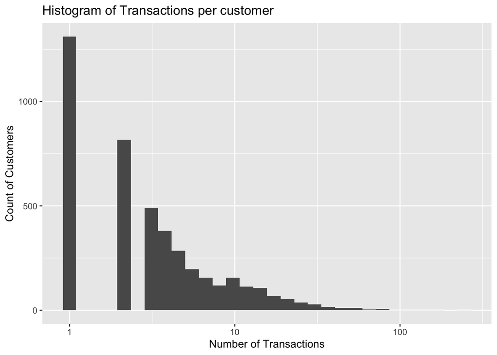

```r
ggplot(custSummary, aes(transactions)) + geom_histogram() + scale_x_log10() + labs(x = 'Number of Transactions', y = 'Count of Customers', title = 'Histogram of Transactions per customer')
```

```r
custSummaryB <- custData %>%
  group_by(CustomerID, InvoiceNo) %>%
  summarise(revenue = sum(lineTotal), transactions = n_distinct(InvoiceNo)) %>%
  mutate(aveOrdVal = (round((revenue / transactions),2))) %>%
  ungroup() %>%
  arrange(revenue) %>%
  mutate(cumsum=cumsum(revenue))
head(custSummaryB, n =10)
```

```
## # A tibble: 10 × 6
##    CustomerID InvoiceNo  revenue transactions aveOrdVal   cumsum
##         <dbl> <chr>        <dbl>        <int>     <dbl>    <dbl>
##  1      16446 C581484   -168470.            1  -168470. -168470.
##  2      12346 C541433    -77184.            1   -77184. -245653.
##  3      15098 C556445    -38970             1   -38970  -284623.
##  4      15749 C550456    -22998.            1   -22998. -307622.
##  5      16029 C570556    -11817.            1   -11817. -319438.
##  6      12536 C573079     -8322.            1    -8322. -327760.
##  7      16029 C551685     -8143.            1    -8143. -335903.
##  8      16029 C551699     -6930             1    -6930  -342833.
##  9      12744 C571750     -6068.            1    -6068. -348901.
## 10      14911 C562375     -4345.            1    -4345. -353246.
```

```r
custData %>% filter(CustomerID == 16446)
```

```
## # A tibble: 4 × 20
##   InvoiceNo StockCode Description      Quantity InvoiceDate UnitPrice CustomerID
##   <chr>     <chr>     <chr>               <dbl> <chr>           <dbl>      <dbl>
## 1 553573    22980     PANTRY SCRUBBIN…        1 2011-05-18…      1.65      16446
## 2 553573    22982     PANTRY PASTRY B…        1 2011-05-18…      1.25      16446
## 3 581483    23843     PAPER CRAFT , L…    80995 2011-12-09…      2.08      16446
## 4 C581484   23843     PAPER CRAFT , L…   -80995 2011-12-09…      2.08      16446
## # ℹ 13 more variables: Country <fct>, Gender <chr>, Age <dbl>,
## #   PaymentMethod <chr>, Previous_Purchases <dbl>, review <chr>, date <date>,
## #   time <chr>, month <fct>, year <fct>, hourOfDay <fct>, dayOfWeek <ord>,
## #   lineTotal <dbl>
```

It looks like, after buying a scrubbing brush and a pastry brush, this customer returned seven months’ later, added 80,995 Paper Craft Little Birdies to their cart and checked out with an order for £168,470. I don’t know about you, but I think my card prodivder would get a bit upset if I tried to make that sort of online purchase. The little birdies were refunded 12 minutes later.

Looking at the rest of the cumulative data, it seems as though there are quite a lot of high-quantity sales and refunds. Before continuing with this analysis in a real-world situation, it would be advantagous to speak with the e-commerce department to get some insight into the business, the website and checkout design and the types of customers. Are there a number of B2B customers who place very large orders for example?

However, for the purposes of this kernel, we’ll accept that we are aware of these transactions, and continue. It does look as though many of these large transactions are refunded, so if we sum the revenue, we should be working with some reasonable numbers.

```r
custSummaryB <- custData %>%
  group_by(InvoiceNo, CustomerID, Country, date, month, year, hourOfDay, dayOfWeek) %>%
  summarise(orderVal = sum(lineTotal)) %>%
  mutate(recent = Sys.Date() - date) %>%
  ungroup()
```

[output not shown]

```r
custSummaryB$recent <- as.character(custSummaryB$recent)
custSummaryB$recentDays <- sapply(custSummaryB$recent, FUN = function(x) {strsplit(x, split = '[ ]')[[1]][1]})
custSummaryB$recentDays <- as.integer(custSummaryB$recentDays)

head(custSummaryB, n = 5)
```

```
## # A tibble: 5 × 11
##   InvoiceNo CustomerID Country        date       month year  hourOfDay dayOfWeek
##   <chr>          <dbl> <fct>          <date>     <fct> <fct> <fct>     <ord>
## 1 536365         17850 United Kingdom 2010-12-01 2010… <NA>  08        Wednesday
## 2 536366         17850 United Kingdom 2010-12-01 2010… <NA>  08        Wednesday
## 3 536367         13047 United Kingdom 2010-12-01 2010… <NA>  08        Wednesday
## 4 536368         13047 United Kingdom 2010-12-01 2010… <NA>  08        Wednesday
## 5 536369         13047 United Kingdom 2010-12-01 2010… <NA>  08        Wednesday
## # ℹ 3 more variables: orderVal <dbl>, recent <chr>, recentDays <int>
```

```r
customerBreakdown <- custSummaryB %>%
  group_by(CustomerID, Country) %>%
  summarise(orders = n_distinct(InvoiceNo), revenue = sum(orderVal), meanRevenue = round(mean(orderVal), 2), medianRevenue = median(orderVal),
            mostDay = names(which.max(table(dayOfWeek))), mostHour = names(which.max(table(hourOfDay))),
           recency = min(recentDays))%>%
  ungroup()
head(customerBreakdown)
```

```
## # A tibble: 6 × 9
##   CustomerID Country   orders revenue meanRevenue medianRevenue mostDay mostHour
##        <dbl> <fct>      <int>   <dbl>       <dbl>         <dbl> <chr>   <chr>
## 1      12346 United K…      2      0           0             0  Tuesday 10
## 2      12347 Iceland        7   4310         616.          585. Tuesday 14
## 3      12348 Finland        4   1797.        449.          338. Tuesday 10
## 4      12349 Italy          1   1758.       1758.         1758. Monday  09
## 5      12350 Norway         1    334.        334.          334. Wednes… 16
## 6      12352 Norway        11   1545.        140.          160. Tuesday 14
## # ℹ 1 more variable: recency <int>
```

```r
custBreakSum <- customerBreakdown %>%
  filter(orders > 1, revenue > 50)

head(custBreakSum)
```

```
## # A tibble: 6 × 9
##   CustomerID Country  orders revenue meanRevenue medianRevenue mostDay  mostHour
##        <dbl> <fct>     <int>   <dbl>       <dbl>         <dbl> <chr>    <chr>
## 1      12347 Iceland       7   4310         616.          585. Tuesday  14
## 2      12348 Finland       4   1797.        449.          338. Tuesday  10
## 3      12352 Norway       11   1545.        140.          160. Tuesday  14
## 4      12356 Portugal      3   2811.        937.          481. Tuesday  08
## 5      12358 Austria       2   1168.        584.          584. Tuesday  10
## 6      12359 Cyprus        6   6216.       1036.          814. Wednesd… 12
## # ℹ 1 more variable: recency <int>
```

```r
dim(custBreakSum)
```

```
## [1] 3031    9
```

```r
library(heatmaply)
custMat <- custBreakSum %>%
  select(recency, revenue, meanRevenue, medianRevenue, orders) %>%
  as.matrix()

rownames(custMat) <- custBreakSum$CustomerID

head(custMat)
```

```
##       recency revenue meanRevenue medianRevenue orders
## 12347    4546 4310.00      615.71        584.91      7
## 12348    4619 1797.24      449.31        338.50      4
## 12352    4580 1545.41      140.49        160.33     11
## 12356    4566 2811.43      937.14        481.46      3
## 12358    4545 1168.06      584.03        584.03      2
## 12359    4551 6215.83     1035.97        813.56      6
```

```r
class(custMat)
```

```
## [1] "matrix" "array"
```

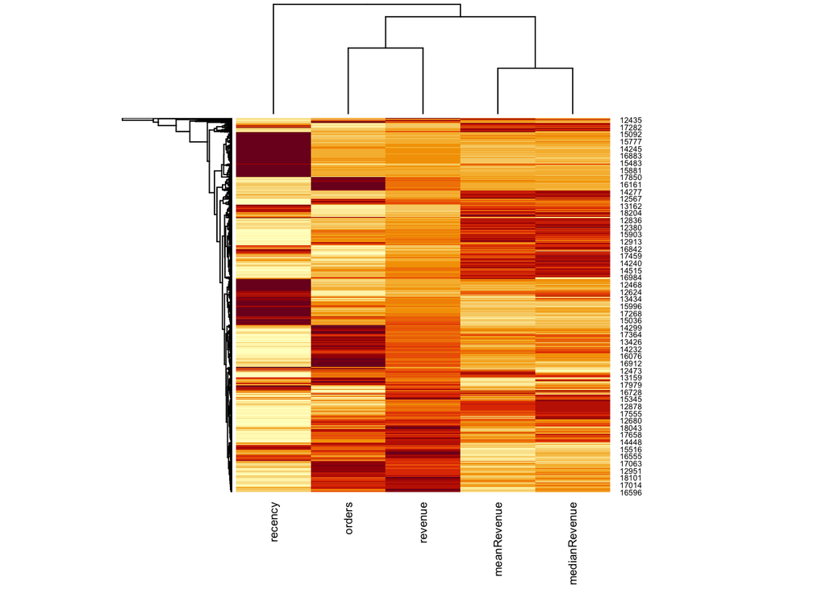

```r
options(repr.plot.width=7, repr.plot.height=6)
heatmap(scale(custMat), cexCol = 0.7)
```

Looking at the heatmap, we can see that the total revenue clusters with the number of orders as we would expect, that the mean and median order values cluster together, again, as expected, and that the order recency sits in its own group. However, the main point of interest here is how the rows (customers) cluster.

By analysing the data in this way, we can uncover groups of customers that behavve in similar ways. This level of customer segmentation is useful in marketing to these groups of customers appropriately. A marketing campaign that works for a group of customers that places low value orders frequently may not be appropriate for customers who place sporadic, high value orders for example.

Summary and conclusions This dataset offers myriad opportunities for practising skills in e-commerce sales analysis and customer segmentation. There are some other variables it would be nice to have in the dataset such as categories for the products. Additionally, before performing analysis it would be important to talk with the e-commerce team to understand the business and its customers and its strategic and tactical objectives. Knowing what the business wants to achieve, and what questions it has are central to performing a relevant analysis that generates actionable insight.

Of course, there is still a lot more that we can do with this dataset. We haven’t looked at the frequency of purchases, and we’ve not looked at the products. While a simple ‘product category’ variable would have been very useful. We may well be able to extract some additional features from the description field with some text analysis, and we could look at using the stock code, perhaps using PCA to reduce the dimensionality, but that’s perhaps for another notebook.

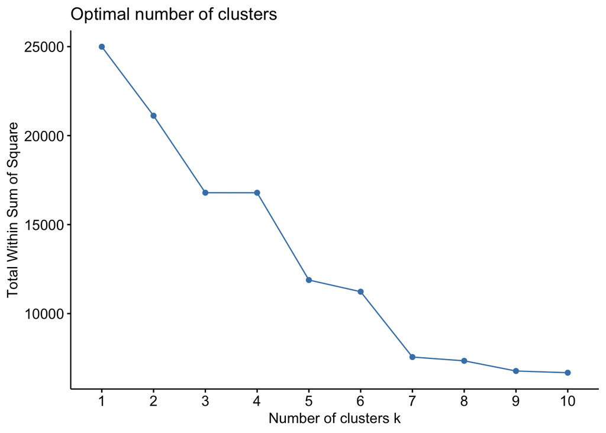

```r
library(factoextra)
custData_sample <- custData %>% sample_n(5000)
clustering_data <- custData_sample %>%
  select(Quantity, UnitPrice, Age, Previous_Purchases, lineTotal) # Modify as needed

# Handle missing values if any
clustering_data <- na.omit(clustering_data)

# Scale the data
clustering_data_scaled <- scale(clustering_data)

# Determine the optimal number of clusters using the Elbow method
fviz_nbclust(clustering_data_scaled, kmeans, method = "wss")
```

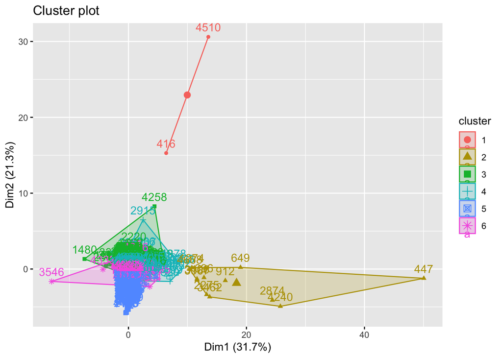

```r
# Apply K-means clustering with the chosen number of clusters
set.seed(123) # For reproducibility
kmeans_result <- kmeans(clustering_data_scaled, centers = 6, nstart = 25)

# Add cluster results to the original data
custData_sample$Cluster <- kmeans_result$cluster

# Visualize the clustering results using PCA
fviz_cluster(kmeans_result, data = clustering_data_scaled)
```

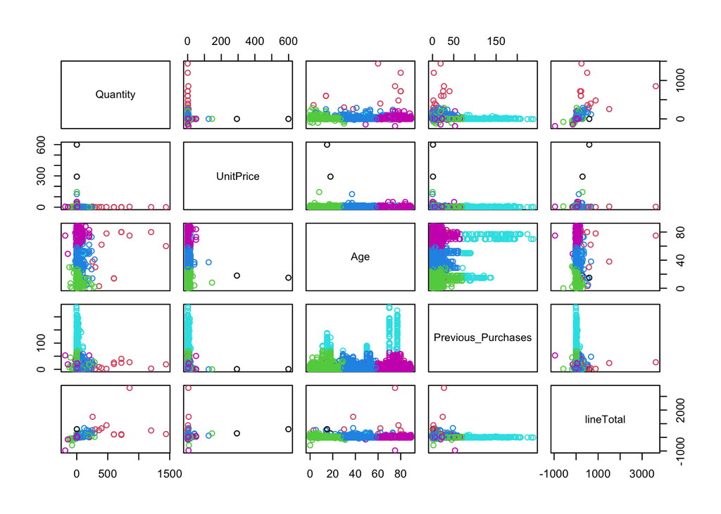

```r
# Or use a pair plot if the number of features is small
pairs(clustering_data, col = custData_sample$Cluster)
```